# slide_deck slides

## Fordgobike tripdata (02/2019) Analysis

### Investigation Overview

In this investigation I wanted to explore main features of fordgobike tripdata fro the month of February covering the greater San Francisco Bay area. The objective of this investigation is to look into the relationship between trip duration with other categorical variables in the datset and answer the questions like:

- how does the trip duration look like?
- how does the trip duration differ by member_age, member_gender, user_type and start_hour?
- what days and which hours have highest demand for trips?
- how long are the rides taken by the user_type?
- what is the percentage of member_gender taking the rides?

### Dataset Overview

The dataset contains 174952 rows and 17 columns for Ford GoBike System, which covers the greater San Francisco Bay area. The dataset contains:

- trip duration
- start/end time for bike rides
- start date for bike rides
- start/end station names
- customer data

### Trip Duration

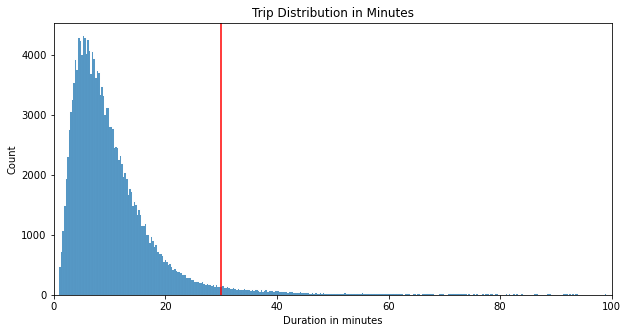

### Time Vs Demand for bikes

Peak hours are those from 7am - 9am and 4pm - 6pm. This might be related to the time when employees and students go to and leave work and school. From the plot we can say that the demand for bikes are high during these peak hours.

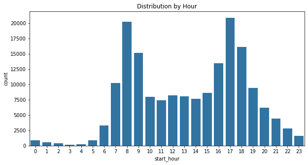

### Trip distribution over day of the week

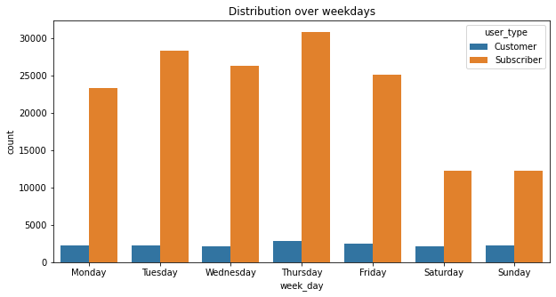

### Duration of rides between user types

From the plot it observed that subscribers ride shorter rides compared to customers. In other way, we can also say that customers have longer trips on each day of the week compared to subscribers. It can be further considered that subscribers are mostly the employees and students who take the ride to work and school and vice-versa.

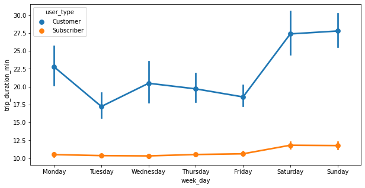